# CA2 Part B Reinforcement Learning

- Jayden Yap p2112790
- Nathan Yeo p2123082

## The Lunar Lander Environment

Lunar Lander is a popular reinforcement learning (RL) environment where an agent must control a lunar lander ship to land safely on the moon's surface. The goal of the agent is to maximize the total reward obtained by landing the lander in a landing area while avoiding obstacles.

In this environment, the state of the environment includes variables like the position, velocity, and angle of the lunar lander. The agent must choose one of several possible actions at each time step, such as increasing or decreasing the thrust in one of the engines. The agent receives a reward based on the state of the lander and the chosen action, with larger rewards for landing safely and smaller rewards (or penalties) for crashing or using too much fuel.

The Lunar Lander environment is a challenging problem for reinforcement learning algorithms, as it requires balancing multiple objectives and trade-offs, such as controlling the speed and trajectory of the lander, conserving fuel, and avoiding obstacles. This makes it a popular benchmark environment for testing and comparing different RL algorithms.

State Variables: 8 total

- x-coordinates
- y-coordinates
- x-velocity
- y-velocity
- angle of ship
- angular velocity (rate of turning)
- left-touch (whether left leg in contact with ground)
- right-touch (whether right leg in contact with ground)

Action Space: 4 total

- Do nothing
- Fire left engine
- Fire main engine
- Fire right engine

## Install/Import packages

```python
# !pip install gym[box2d]
# !pip install pygame
# !pip install gym==0.25.2
```

```python
save_dir = "0-COLLAB"
```

```python
import os
# os.environ['SDL_VIDEODRIVER']='dummy' #for use in collab/cant open pygame window
import pygame
pygame.display.set_mode((640,480))
```

```
pygame 2.1.0 (SDL 2.0.16, Python 3.8.13)
Hello from the pygame community. https://www.pygame.org/contribute.html
```

```
<Surface(640x480x32 SW)>
```

```python
#hide warning for better outputs
import warnings
warnings.filterwarnings("ignore")
```

```python
#hide more warnings
%%javascript
(function(on) {
    const e = $("<a>Setup failed</a>");
    const ns = "js_jupyter_suppress_warnings";
    var cssrules = $("#" + ns);
    if(!cssrules.length)
        cssrules = $("<style id='" + ns + "' type='text/css'>div.output_stderr { } </style>").appendTo("head");
    e.click(function() {
        var s = 'Showing';
        cssrules.empty()
        if(on) {
            s = 'Hiding';
            cssrules.append("div.output_stderr, div[data-mime-type*='.stderr'] { display:none; }");
        }
        e.text(s + ' warnings (click to toggle)');
        on = !on;
    }).click();
    $(element).append(e);
})(true);
```

```python
import gym
import numpy as np
import pandas as pd
import matplotlib.pyplot as plt
from collections import deque
import random
import tensorflow as tf
from tensorflow.keras import layers


import pickle
from matplotlib import pyplot as plt
```

```python
#lower vram usage
physical_devices = tf.config.experimental.list_physical_devices('GPU')
for i in physical_devices:
    tf.config.experimental.set_memory_growth(i, True)
```

## Main Code Functions

```python
def test_already_trained_model(trained_model,episodes=10,render=True):
    rewards_list = []
    num_test_episode = episodes
    env = gym.make("LunarLander-v2")
    print("Starting Testing of the trained model...")

    step_count = 1000

    for test_episode in range(num_test_episode):
        current_state = env.reset()
        num_observation_space = env.observation_space.shape[0]
        current_state = np.reshape(current_state, [1, num_observation_space])
        reward_for_episode = 0
        for step in range(step_count):
            if render:
              env.render()
            selected_action = np.argmax(trained_model.predict(current_state)[0])
            new_state, reward, done, info = env.step(selected_action)
            new_state = np.reshape(new_state, [1, num_observation_space])
            current_state = new_state
            reward_for_episode += reward
            if done:
                break
        rewards_list.append(reward_for_episode)
        print(test_episode, "\t: Episode || Reward: ", reward_for_episode)

    return rewards_list


def plot_df(df, chart_name, title, x_axis_label, y_axis_label):
    plt.rcParams.update({'font.size': 17})
    df['rolling_mean'] = df[df.columns[0]].rolling(100).mean()
    plt.figure(figsize=(15, 8))
    plt.close()
    plt.figure()
    # plot = df.plot(linewidth=1.5, figsize=(15, 8), title=title)
    plot = df.plot(linewidth=1.5, figsize=(15, 8))
    plot.set_xlabel(x_axis_label)
    plot.set_ylabel(y_axis_label)
    # plt.ylim((-400, 300))
    fig = plot.get_figure()
    plt.legend().set_visible(False)
    fig.savefig(save_dir+f'/{chart_name}')


def plot_df2(df, chart_name, title, x_axis_label, y_axis_label):
    df['mean'] = df[df.columns[0]].mean()
    plt.rcParams.update({'font.size': 17})
    plt.figure(figsize=(15, 8))
    plt.close()
    plt.figure()
    # plot = df.plot(linewidth=1.5, figsize=(15, 8), title=title)
    plot = df.plot(linewidth=1.5, figsize=(15, 8))
    plot.set_xlabel(x_axis_label)
    plot.set_ylabel(y_axis_label)
    plt.ylim((0, 300))
    plt.xlim((0, 100))
    plt.legend().set_visible(False)
    fig = plot.get_figure()
    fig.savefig(save_dir+f'/{chart_name}')


def plot_experiments(df, chart_name, title, x_axis_label, y_axis_label, y_limit):
    plt.rcParams.update({'font.size': 17})
    plt.figure(figsize=(15, 8))
    plt.close()
    plt.figure()
    plot = df.plot(linewidth=1, figsize=(15, 8), title=title)
    plot.set_xlabel(x_axis_label)
    plot.set_ylabel(y_axis_label)
    plt.ylim(y_limit)
    fig = plot.get_figure()
    fig.savefig(save_dir+f'/{chart_name}')


def run_experiment_for_gamma():
    print('Running Experiment for gamma...')
    env = gym.make('LunarLander-v2')

    # set seeds
    env.seed(21)
    np.random.seed(21)

    # setting up params
    lr = 0.001
    epsilon = 1.0
    epsilon_decay = 0.995
    gamma_list = [0.99, 0.9, 0.8, 0.7]
    training_episodes = 1000

    rewards_list_for_gammas = []
    for gamma_value in gamma_list:
        model = DQN(env, lr, gamma_value, epsilon, epsilon_decay)
        print("Training model for Gamma: {}".format(gamma_value))
        model.train(training_episodes, False)
        rewards_list_for_gammas.append(model.rewards_list)

    pickle.dump(rewards_list_for_gammas, open("rewards_list_for_gammas.p", "wb"))
    rewards_list_for_gammas = pickle.load(open("rewards_list_for_gammas.p", "rb"))

    gamma_rewards_pd = pd.DataFrame(index=pd.Series(range(1, training_episodes + 1)))
    for i in range(len(gamma_list)):
        col_name = "gamma=" + str(gamma_list[i])
        gamma_rewards_pd[col_name] = rewards_list_for_gammas[i]
    plot_experiments(gamma_rewards_pd, "Figure 4: Rewards per episode for different gamma values",
                     "Figure 4: Rewards per episode for different gamma values", "Episodes", "Reward", (-600, 300))


def run_experiment_for_lr():
    print('Running Experiment for learning rate...')
    env = gym.make('LunarLander-v2')

    # set seeds
    env.seed(21)
    np.random.seed(21)

    # setting up params
    lr_values = [0.0001, 0.001, 0.01, 0.1]
    epsilon = 1.0
    epsilon_decay = 0.995
    gamma = 0.99
    training_episodes = 1000
    rewards_list_for_lrs = []
    for lr_value in lr_values:
        model = DQN(env, lr_value, gamma, epsilon, epsilon_decay)
        print("Training model for LR: {}".format(lr_value))
        model.train(training_episodes, False)
        rewards_list_for_lrs.append(model.rewards_list)

    pickle.dump(rewards_list_for_lrs, open("rewards_list_for_lrs.p", "wb"))
    rewards_list_for_lrs = pickle.load(open("rewards_list_for_lrs.p", "rb"))

    lr_rewards_pd = pd.DataFrame(index=pd.Series(range(1, training_episodes + 1)))
    for i in range(len(lr_values)):
        col_name = "lr="+ str(lr_values[i])
        lr_rewards_pd[col_name] = rewards_list_for_lrs[i]
    plot_experiments(lr_rewards_pd, "Figure 3: Rewards per episode for different learning rates", "Figure 3: Rewards per episode for different learning rates", "Episodes", "Reward", (-2000, 300))


def run_experiment_for_ed():
    print('Running Experiment for epsilon decay...')
    env = gym.make('LunarLander-v2')

    # set seeds
    env.seed(21)
    np.random.seed(21)

    # setting up params
    lr = 0.001
    epsilon = 1.0
    ed_values = [0.999, 0.995, 0.990, 0.9]
    gamma = 0.99
    training_episodes = 1000

    rewards_list_for_ed = []
    for ed in ed_values:
        save_dir = "hp_ed_"+ str(ed) + "_"
        model = DQN(env, lr, gamma, epsilon, ed)
        print("Training model for ED: {}".format(ed))
        model.train(training_episodes, False)
        rewards_list_for_ed.append(model.rewards_list)

    pickle.dump(rewards_list_for_ed, open("rewards_list_for_ed.p", "wb"))
    rewards_list_for_ed = pickle.load(open("rewards_list_for_ed.p", "rb"))

    ed_rewards_pd = pd.DataFrame(index=pd.Series(range(1, training_episodes+1)))
    for i in range(len(ed_values)):
        col_name = "epsilon_decay = "+ str(ed_values[i])
        ed_rewards_pd[col_name] = rewards_list_for_ed[i]
    plot_experiments(ed_rewards_pd, "Figure 5: Rewards per episode for different epsilon(ε) decay", "Figure 5: Rewards per episode for different epsilon(ε) decay values", "Episodes", "Reward", (-600, 300))
```

## Building Actor Critic Network

The Actor-Critic network is a RL method that combines the actor and critic components into a single model. The actor component learns the policy that maps states to actions, while the critic component evaluates the quality of the actions taken by the actor and provides it with a error signal to guide improvement of the policy.

### Init parameters and environment

```python
gamma = 0.99  # Discount factor for past rewards
max_steps_per_episode = 1000
max_episodes=2000
#init environment
env = gym.make('LunarLander-v2')
# set seeds
env.seed(21)
np.random.seed(21)
eps = np.finfo(np.float32).eps.item()  # Smallest number such that 1.0 + eps != 1.0
```

### Build Model

```python
num_inputs = 8
num_actions = 4
num_hidden = 512

inputs = layers.Input(shape=(num_inputs,))
common1 = layers.Dense(num_hidden, activation="relu")(inputs)
common = layers.Dense(num_hidden, activation="relu")(common1)
action = layers.Dense(num_actions, activation="softmax")(common)
critic = layers.Dense(1)(common)

model = tf.keras.Model(inputs=inputs, outputs=[action, critic])
model.summary()
```

```
Model: "model_5"
__________________________________________________________________________________________________
 Layer (type)                   Output Shape         Param #     Connected to
==================================================================================================
 input_6 (InputLayer)           [(None, 8)]          0           []

 dense_18 (Dense)               (None, 512)          4608        ['input_6[0][0]']

 dense_19 (Dense)               (None, 512)          262656      ['dense_18[0][0]']

 dense_20 (Dense)               (None, 4)            2052        ['dense_19[0][0]']

 dense_21 (Dense)               (None, 1)            513         ['dense_19[0][0]']

==================================================================================================
Total params: 269,829
Trainable params: 269,829
Non-trainable params: 0
__________________________________________________________________________________________________
```

### Training

```python
optimizer = tf.keras.optimizers.Adam(learning_rate=0.001)
huber_loss = tf.keras.losses.Huber()
action_probs_history = []
critic_value_history = []
rewards_history = []
running_reward = 0
episode_count = 0

while episode_count<max_episodes:  # Run until exceed reward threshold or maximum episodes
    state = env.reset()
    episode_reward = 0
    with tf.GradientTape() as tape:
        for timestep in range(1, max_steps_per_episode):
          # env.render()
          state = tf.convert_to_tensor(state)
          state = tf.expand_dims(state, 0)
          # Predict action probabilities and estimatedfuture rewards from env state
          action_probs, critic_value = model(state)
          critic_value_history.append(critic_value[0, 0])

          # Sample from action distribution
          action = np.random.choice(num_actions, p=np.squeeze(action_probs))
          action_probs_history.append(tf.math.log(action_probs[0, action]))

          # Apply the sampled action
          state, reward, done, _ = env.step(action)
          rewards_history.append(reward)
          episode_reward += reward

          if done:
            break

        # Update running reward
        running_reward = 0.05 * episode_reward + (1 - 0.05) * running_reward

        # Calculate expected value from rewards
        # - At each timestep what was the total reward received after that timestep
        # - Rewards in the past are discounted by multiplying them with gamma
        # - These are the labels for our critic
        returns = []
        discounted_sum = 0
        for r in rewards_history[::-1]:
            discounted_sum = r + gamma * discounted_sum
            returns.insert(0, discounted_sum)

        # Normalize
        returns = np.array(returns)
        returns = (returns - np.mean(returns)) / (np.std(returns) + eps)
        returns = returns.tolist()

        # Calculating loss values to update our network
        history = zip(action_probs_history, critic_value_history, returns)
        actor_losses = []
        critic_losses = []
        for log_prob, value, ret in history:
            # At this point in history, the critic estimated that we would get a
            # total reward = `value` in the future. We took an action with log probability
            # of `log_prob` and ended up recieving a total reward = `ret`.
            # The actor must be updated so that it predicts an action that leads to
            # high rewards (compared to critic's estimate) with high probability
            diff = ret - value
            actor_losses.append(-log_prob * diff)  # actor loss

            # The critic must be updated so that it predicts a better estimate of
            # the future rewards.
            critic_losses.append(
                huber_loss(tf.expand_dims(value, 0), tf.expand_dims(ret, 0))
            )

        # Backpropagation
        loss_value = sum(actor_losses) + sum(critic_losses)
        grads = tape.gradient(loss_value, model.trainable_variables)
        optimizer.apply_gradients(zip(grads, model.trainable_variables))

        # Clear the loss and reward history
        action_probs_history.clear()
        critic_value_history.clear()
        rewards_history.clear()

    # Log details
    episode_count += 1
    print(f'Episode {episode_count}: {episode_reward}')
    if episode_count % 10 == 0:
        print(f"running reward: {running_reward:.2f} at episode {episode_count}")

    if running_reward > 0:  # Condition to consider a decent model
        print(f"Solved at episode {episode_count}!")
        break
```

```
Episode 1: -89.01693684293888
Episode 2: -83.13288203978885
Episode 3: -87.56077029621338
Episode 4: -82.3143106389022
Episode 5: -293.52448526114426
Episode 6: -133.04932795256542
Episode 7: -71.37376522370818
Episode 8: -91.98906247938741
Episode 9: -113.20723957267126
Episode 10: -74.8811174194572
running reward: -44.75 at episode 10
Episode 11: -462.1710650093039
Episode 12: -396.54848719597624
Episode 13: -158.42861549805792
Episode 14: -136.810253293936
Episode 15: -113.09046741557616
Episode 16: -144.79322115211545
Episode 17: -490.74049645883923
Episode 18: -311.62820520385526
Episode 19: -76.16346871357419
Episode 20: -290.56005489843375
running reward: -128.59 at episode 20
Episode 21: 18.48304849472585
Episode 22: -560.0585881618515
Episode 23: -548.3781868840131
Episode 24: -508.49934170752607
Episode 25: -705.1505600838441
Episode 26: -446.2240846550956
Episode 27: -597.2194944209673
Episode 28: -425.86746506031824
Episode 29: -230.76559168041757
Episode 30: -321.88036986241195
running reward: -250.15 at episode 30
Episode 31: -1212.5608871579705
Episode 32: -543.8645601045763
Episode 33: -166.74548638725557
Episode 34: -139.48739563470545
Episode 35: -638.5870932383796
Episode 36: -198.16942443366713
Episode 37: -82.23151061937605
```

[output cut: 341 more lines]

```
Episode 348: -720.9247095421637
Episode 349: -441.3828937296971
Episode 350: -394.0427964084638
running reward: -508.63 at episode 350
Episode 351: -536.8979664506372
Episode 352: -357.19076333641743
Episode 353: -727.5050827371166
Episode 354: -523.8092540405415
Episode 355: -724.6150641864348
Episode 356: -341.77303020901877
Episode 357: -528.4177782980912
Episode 358: -604.140393184405
Episode 359: -416.6021080328764
Episode 360: -723.5315975047458
running reward: -525.79 at episode 360
```

[output not shown]

### Save and test model

```python
model.save('0-COLLAB/savedModels/ActorCritic.h5')
```

```
WARNING:tensorflow:Compiled the loaded model, but the compiled metrics have yet to be built. `model.compile_metrics` will be empty until you train or evaluate the model.
```

```python
ACmodel=tf.keras.models.load_model('0-COLLAB/savedModels/ActorCritic.h5')
```

```
WARNING:tensorflow:No training configuration found in the save file, so the model was *not* compiled. Compile it manually.
```

```python
test_rewards = test_already_trained_model(ACmodel,episodes=100,render=True)
```

```
Starting Testing of the trained model...
0 	: Episode || Reward:  -136.79903649447817
1 	: Episode || Reward:  -212.48132774883197
2 	: Episode || Reward:  -206.99395928987283
3 	: Episode || Reward:  -97.62042552318435
4 	: Episode || Reward:  -150.67667386438197
5 	: Episode || Reward:  -166.67148081995882
6 	: Episode || Reward:  -123.9904434239938
7 	: Episode || Reward:  -318.4000077040148
8 	: Episode || Reward:  -137.23536482657306
9 	: Episode || Reward:  -143.4882089521803
10 	: Episode || Reward:  -147.25897201332313
11 	: Episode || Reward:  -142.37004826899738
12 	: Episode || Reward:  -107.51564829555431
13 	: Episode || Reward:  -125.96539348263802
```

[output cut: 86 more lines]

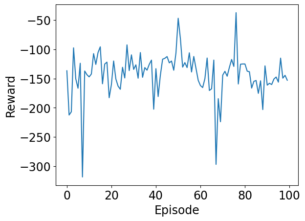

```python
plt.plot(test_rewards)
plt.ylabel('Reward')
plt.xlabel('Episode')
plt.show()
```

## Deep SARSA (State-Action-Reward-State-Action)

SARSA is a model-free RL algorithm that learns by updating the Q-value for a current state-action pair based on the reward and the estimated Q-value for the next state-action pair. This helps the agent make decisions because it has a better idea of the long-term reward of each possible action in a given state.

- Using keras-RL library so we can easily test out different Policies and see the effect on the SARSA architecture
- Save the model with best mean reward at the end of training

```python
#!pip install keras-rl
```

### Boltzmann Q Policy

Selects actions based on the Boltzmann distribution over Q-values. It has a good balance of exploration and exploitation because it selects actions with higher Q-values more often, but also considers actions with lower Q-values sometimes

```python
from tensorflow.keras.models import Sequential
from tensorflow.keras.layers import Dense, Activation, Flatten
from tensorflow.keras.optimizers import Adam

from rl.agents import SARSAAgent
from rl.policy import BoltzmannQPolicy, GreedyQPolicy, BoltzmannGumbelQPolicy, MaxBoltzmannQPolicy

ENV_NAME = 'LunarLander-v2'
```

```python
# Get environment
env = gym.make(ENV_NAME)
np.random.seed(21)
env.seed(21)
nb_actions = 4

# Build model
model = Sequential()
model.add(Flatten(input_shape=(1,) + env.observation_space.shape))
model.add(Dense(256))
model.add(Activation('relu'))
model.add(Dense(256))
model.add(Activation('relu'))
model.add(Dense(256))
model.add(Activation('relu'))
model.add(Dense(nb_actions))
model.add(Activation('linear'))
print(model.summary())

# Select policy
policy = BoltzmannQPolicy()
# policy = GreedyQPolicy()
# policy = BoltzmannGumbelQPolicy()
sarsa1 = SARSAAgent(model=model, nb_actions=nb_actions, nb_steps_warmup=10, gamma=0.99, policy=policy)
sarsa1.compile(Adam(lr=0.001), metrics=['mae'])
sarsa1.fit(env, nb_steps=70000, visualize=False, verbose=2)
```

```
Model: "sequential_9"
_________________________________________________________________
 Layer (type)                Output Shape              Param #
=================================================================
 flatten_9 (Flatten)         (None, 8)                 0

 dense_58 (Dense)            (None, 256)               2304

 activation_36 (Activation)  (None, 256)               0

 dense_59 (Dense)            (None, 256)               65792

 activation_37 (Activation)  (None, 256)               0

 dense_60 (Dense)            (None, 256)               65792

 activation_38 (Activation)  (None, 256)               0

 dense_61 (Dense)            (None, 4)                 1028

 activation_39 (Activation)  (None, 4)                 0

=================================================================
Total params: 134,916
Trainable params: 134,916
Non-trainable params: 0
_________________________________________________________________
```

```
None
Training for 70000 steps ...
   185/70000: episode: 1, duration: 4.750s, episode steps: 185, steps per second: 39, episode reward: -379.562, mean reward: -2.052 [-100.000, 11.987], mean action: 1.595 [0.000, 3.000], mean observation: 0.250 [-1.395, 4.050],
   299/70000: episode: 2, duration: 2.812s, episode steps: 114, steps per second: 41, episode reward: -607.501, mean reward: -5.329 [-100.000, 2.315], mean action: 1.500 [0.000, 3.000], mean observation: 0.358 [-4.223, 4.935],
   361/70000: episode: 3, duration: 1.703s, episode steps: 62, steps per second: 36, episode reward: -133.581, mean reward: -2.155 [-100.000, 6.178], mean action: 0.048 [0.000, 3.000], mean observation: -0.065 [-1.865, 5.773],
   413/70000: episode: 4, duration: 1.426s, episode steps: 52, steps per second: 36, episode reward: -81.388, mean reward: -1.565 [-100.000, 14.209], mean action: 0.000 [0.000, 0.000], mean observation: -0.048 [-1.921, 1.385],
   475/70000: episode: 5, duration: 1.742s, episode steps: 62, steps per second: 36, episode reward: -112.942, mean reward: -1.822 [-100.000, 16.758], mean action: 0.000 [0.000, 0.000], mean observation: -0.006 [-1.844, 1.401],
   548/70000: episode: 6, duration: 1.791s, episode steps: 73, steps per second: 41, episode reward: -175.499, mean reward: -2.404 [-100.000, 6.856], mean action: 0.000 [0.000, 0.000], mean observation: 0.078 [-1.845, 5.883],
   607/70000: episode: 7, duration: 1.487s, episode steps: 59, steps per second: 40, episode reward: -127.598, mean reward: -2.163 [-100.000, 6.824], mean action: 0.000 [0.000, 0.000], mean observation: -0.001 [-1.853, 1.397],
   682/70000: episode: 8, duration: 1.903s, episode steps: 75, steps per second: 39, episode reward: -188.095, mean reward: -2.508 [-100.000, 6.553], mean action: 0.000 [0.000, 0.000], mean observation: -0.062 [-5.503, 1.425],
   759/70000: episode: 9, duration: 1.976s, episode steps: 77, steps per second: 39, episode reward: -138.248, mean reward: -1.795 [-100.000, 7.296], mean action: 0.000 [0.000, 0.000], mean observation: -0.007 [-6.359, 1.429],
   863/70000: episode: 10, duration: 2.545s, episode steps: 104, steps per second: 41, episode reward: -275.420, mean reward: -2.648 [-100.000, 141.160], mean action: 0.087 [0.000, 3.000], mean observation: 0.024 [-3.745, 1.517],
   958/70000: episode: 11, duration: 2.284s, episode steps: 95, steps per second: 42, episode reward: -561.328, mean reward: -5.909 [-100.000, -0.393], mean action: 1.916 [0.000, 3.000], mean observation: 0.118 [-3.535, 1.633],
  1036/70000: episode: 12, duration: 1.981s, episode steps: 78, steps per second: 39, episode reward: -421.965, mean reward: -5.410 [-100.000, 1.365], mean action: 1.179 [0.000, 3.000], mean observation: 0.243 [-1.951, 6.358],
  1089/70000: episode: 13, duration: 1.225s, episode steps: 53, steps per second: 43, episode reward: -273.559, mean reward: -5.161 [-100.000, 1.291], mean action: 1.000 [0.000, 3.000], mean observation: 0.213 [-3.069, 1.946],
  1145/70000: episode: 14, duration: 1.352s, episode steps: 56, steps per second: 41, episode reward: -391.453, mean reward: -6.990 [-100.000, 0.337], mean action: 0.893 [0.000, 3.000], mean observation: 0.276 [-1.915, 7.391],
  1216/70000: episode: 15, duration: 1.688s, episode steps: 71, steps per second: 42, episode reward: -138.063, mean reward: -1.945 [-100.000, 11.864], mean action: 0.000 [0.000, 0.000], mean observation: 0.063 [-1.760, 4.601],
  1269/70000: episode: 16, duration: 1.480s, episode steps: 53, steps per second: 36, episode reward: -125.947, mean reward: -2.376 [-100.000, 6.546], mean action: 0.000 [0.000, 0.000], mean observation: -0.082 [-1.892, 1.388],
  1322/70000: episode: 17, duration: 1.272s, episode steps: 53, steps per second: 42, episode reward: -2.171, mean reward: -0.041 [-100.000, 77.036], mean action: 0.000 [0.000, 0.000], mean observation: -0.117 [-4.676, 1.387],
  1376/70000: episode: 18, duration: 1.311s, episode steps: 54, steps per second: 41, episode reward: -150.563, mean reward: -2.788 [-100.000, 6.231], mean action: 0.000 [0.000, 0.000], mean observation: 0.045 [-1.858, 3.810],
  1453/70000: episode: 19, duration: 1.893s, episode steps: 77, steps per second: 41, episode reward: -85.480, mean reward: -1.110 [-100.000, 52.503], mean action: 0.000 [0.000, 0.000], mean observation: 0.060 [-1.764, 3.697],
  1516/70000: episode: 20, duration: 1.523s, episode steps: 63, steps per second: 41, episode reward: -106.595, mean reward: -1.692 [-100.000, 18.559], mean action: 0.000 [0.000, 0.000], mean observation: -0.010 [-1.832, 1.402],
  1580/70000: episode: 21, duration: 1.507s, episode steps: 64, steps per second: 42, episode reward: -135.824, mean reward: -2.122 [-100.000, 7.016], mean action: 0.000 [0.000, 0.000], mean observation: -0.028 [-1.832, 1.403],
  1662/70000: episode: 22, duration: 2.005s, episode steps: 82, steps per second: 41, episode reward: -153.485, mean reward: -1.872 [-100.000, 6.284], mean action: 0.000 [0.000, 0.000], mean observation: 0.004 [-1.870, 5.732],
  1743/70000: episode: 23, duration: 1.980s, episode steps: 81, steps per second: 41, episode reward: -182.776, mean reward: -2.256 [-100.000, 6.547], mean action: 0.000 [0.000, 0.000], mean observation: -0.035 [-5.393, 1.456],
  1828/70000: episode: 24, duration: 2.081s, episode steps: 85, steps per second: 41, episode reward: -119.108, mean reward: -1.401 [-100.000, 22.154], mean action: 0.000 [0.000, 0.000], mean observation: 0.090 [-1.784, 3.391],
```

[output cut: 631 more lines]

```
<keras.callbacks.History at 0x19ec8614df0>
```

### Boltzmann Gumbel Q Policy

Similar to the BoltzmannQPolicy, but uses the Gumbel-Softmax distribution instead of the Boltzmann distribution, more suitable for backpropagation.

```python
# Get environment
env = gym.make(ENV_NAME)
np.random.seed(21)
env.seed(21)
nb_actions = 4

# Build model
model = Sequential()
model.add(Flatten(input_shape=(1,) + env.observation_space.shape))
model.add(Dense(256))
model.add(Activation('relu'))
model.add(Dense(256))
model.add(Activation('relu'))
model.add(Dense(256))
model.add(Activation('relu'))
model.add(Dense(nb_actions))
model.add(Activation('linear'))
print(model.summary())

# Select policy
# policy = BoltzmannQPolicy()
# policy = GreedyQPolicy()
policy = BoltzmannGumbelQPolicy()
sarsa2 = SARSAAgent(model=model, nb_actions=nb_actions, nb_steps_warmup=10, gamma=0.99, policy=policy)
sarsa2.compile(Adam(lr=0.001), metrics=['mae'])
sarsa2.fit(env, nb_steps=70000, visualize=False, verbose=2)
```

```
Model: "sequential_10"
_________________________________________________________________
 Layer (type)                Output Shape              Param #
=================================================================
 flatten_10 (Flatten)        (None, 8)                 0

 dense_62 (Dense)            (None, 256)               2304

 activation_40 (Activation)  (None, 256)               0

 dense_63 (Dense)            (None, 256)               65792

 activation_41 (Activation)  (None, 256)               0

 dense_64 (Dense)            (None, 256)               65792

 activation_42 (Activation)  (None, 256)               0

 dense_65 (Dense)            (None, 4)                 1028

 activation_43 (Activation)  (None, 4)                 0

=================================================================
Total params: 134,916
Trainable params: 134,916
Non-trainable params: 0
_________________________________________________________________
```

```
None
Training for 70000 steps ...
   177/70000: episode: 1, duration: 4.886s, episode steps: 177, steps per second: 36, episode reward: -213.478, mean reward: -1.206 [-100.000, 11.609], mean action: 1.808 [0.000, 3.000], mean observation: 0.259 [-0.870, 3.425],
   287/70000: episode: 2, duration: 2.673s, episode steps: 110, steps per second: 41, episode reward: -460.208, mean reward: -4.184 [-100.000, 3.286], mean action: 1.745 [0.000, 3.000], mean observation: -0.175 [-3.391, 4.187],
   337/70000: episode: 3, duration: 1.231s, episode steps: 50, steps per second: 41, episode reward: -345.864, mean reward: -6.917 [-100.000, -0.321], mean action: 1.000 [1.000, 1.000], mean observation: 0.188 [-2.015, 2.485],
   410/70000: episode: 4, duration: 1.879s, episode steps: 73, steps per second: 39, episode reward: -483.456, mean reward: -6.623 [-100.000, 102.771], mean action: 0.836 [0.000, 1.000], mean observation: 0.371 [-3.124, 4.856],
   475/70000: episode: 5, duration: 1.630s, episode steps: 65, steps per second: 40, episode reward: -561.222, mean reward: -8.634 [-100.000, -0.027], mean action: 1.000 [1.000, 1.000], mean observation: 0.336 [-1.887, 6.480],
   557/70000: episode: 6, duration: 2.030s, episode steps: 82, steps per second: 40, episode reward: -734.964, mean reward: -8.963 [-100.000, 1.819], mean action: 1.000 [1.000, 1.000], mean observation: 0.536 [-4.611, 6.352],
   618/70000: episode: 7, duration: 1.922s, episode steps: 61, steps per second: 32, episode reward: -578.553, mean reward: -9.484 [-100.000, -2.126], mean action: 1.000 [1.000, 1.000], mean observation: 0.217 [-1.946, 4.782],
   668/70000: episode: 8, duration: 1.360s, episode steps: 50, steps per second: 37, episode reward: -406.537, mean reward: -8.131 [-100.000, -1.834], mean action: 1.000 [1.000, 1.000], mean observation: 0.159 [-2.035, 7.639],
   740/70000: episode: 9, duration: 1.733s, episode steps: 72, steps per second: 42, episode reward: -713.309, mean reward: -9.907 [-100.000, 4.304], mean action: 1.000 [1.000, 1.000], mean observation: 0.410 [-1.678, 5.997],
   824/70000: episode: 10, duration: 1.964s, episode steps: 84, steps per second: 43, episode reward: -930.573, mean reward: -11.078 [-100.000, -0.559], mean action: 1.000 [1.000, 1.000], mean observation: 0.547 [-1.850, 8.246],
   879/70000: episode: 11, duration: 1.288s, episode steps: 55, steps per second: 43, episode reward: -463.859, mean reward: -8.434 [-100.000, -2.208], mean action: 1.000 [1.000, 1.000], mean observation: 0.196 [-4.575, 3.292],
   964/70000: episode: 12, duration: 2.003s, episode steps: 85, steps per second: 42, episode reward: -850.105, mean reward: -10.001 [-100.000, 4.552], mean action: 1.000 [1.000, 1.000], mean observation: 0.558 [-1.864, 7.784],
  1029/70000: episode: 13, duration: 1.538s, episode steps: 65, steps per second: 42, episode reward: -526.544, mean reward: -8.101 [-100.000, 0.827], mean action: 1.000 [1.000, 1.000], mean observation: 0.362 [-1.889, 4.217],
  1111/70000: episode: 14, duration: 1.911s, episode steps: 82, steps per second: 43, episode reward: -871.299, mean reward: -10.626 [-100.000, 6.542], mean action: 1.000 [1.000, 1.000], mean observation: 0.504 [-1.765, 7.901],
  1203/70000: episode: 15, duration: 2.292s, episode steps: 92, steps per second: 40, episode reward: -1131.400, mean reward: -12.298 [-100.000, 24.494], mean action: 1.000 [1.000, 1.000], mean observation: 0.603 [-1.840, 10.303],
  1269/70000: episode: 16, duration: 1.726s, episode steps: 66, steps per second: 38, episode reward: -598.574, mean reward: -9.069 [-100.000, -2.172], mean action: 1.000 [1.000, 1.000], mean observation: 0.322 [-1.879, 4.493],
  1319/70000: episode: 17, duration: 1.349s, episode steps: 50, steps per second: 37, episode reward: -305.697, mean reward: -6.114 [-100.000, 1.347], mean action: 1.000 [1.000, 1.000], mean observation: 0.229 [-1.993, 2.268],
  1389/70000: episode: 18, duration: 1.757s, episode steps: 70, steps per second: 40, episode reward: -687.155, mean reward: -9.817 [-100.000, -1.563], mean action: 1.000 [1.000, 1.000], mean observation: 0.371 [-1.750, 5.795],
  1445/70000: episode: 19, duration: 1.353s, episode steps: 56, steps per second: 41, episode reward: -413.466, mean reward: -7.383 [-100.000, -0.268], mean action: 1.000 [1.000, 1.000], mean observation: 0.262 [-1.964, 8.107],
  1521/70000: episode: 20, duration: 1.845s, episode steps: 76, steps per second: 41, episode reward: -777.874, mean reward: -10.235 [-100.000, -1.173], mean action: 1.000 [1.000, 1.000], mean observation: 0.412 [-3.703, 6.479],
  1582/70000: episode: 21, duration: 1.395s, episode steps: 61, steps per second: 44, episode reward: -579.849, mean reward: -9.506 [-100.000, -2.304], mean action: 1.000 [1.000, 1.000], mean observation: 0.214 [-2.009, 4.265],
  1632/70000: episode: 22, duration: 1.174s, episode steps: 50, steps per second: 43, episode reward: -436.448, mean reward: -8.729 [-100.000, -2.036], mean action: 1.000 [1.000, 1.000], mean observation: 0.096 [-5.532, 3.030],
  1704/70000: episode: 23, duration: 1.731s, episode steps: 72, steps per second: 42, episode reward: -698.126, mean reward: -9.696 [-100.000, -1.608], mean action: 1.000 [1.000, 1.000], mean observation: 0.372 [-1.668, 7.128],
  1788/70000: episode: 24, duration: 2.202s, episode steps: 84, steps per second: 38, episode reward: -800.280, mean reward: -9.527 [-100.000, 2.063], mean action: 1.000 [1.000, 1.000], mean observation: 0.562 [-1.847, 7.086],
```

[output cut: 428 more lines]

```
<keras.callbacks.History at 0x19eca82d760>
```

### Max Boltzmann Q Policy

Similar to the BoltzmannQPolicy, but instead of selecting actions based on the Boltzmann distribution, it selects the action with the highest probability after applying a softmax transformation to the Q-values

```python
# Get environment
env = gym.make(ENV_NAME)
np.random.seed(21)
env.seed(21)
nb_actions = 4

# Build model
model = Sequential()
model.add(Flatten(input_shape=(1,) + env.observation_space.shape))
model.add(Dense(256))
model.add(Activation('relu'))
model.add(Dense(256))
model.add(Activation('relu'))
model.add(Dense(256))
model.add(Activation('relu'))
model.add(Dense(nb_actions))
model.add(Activation('linear'))
print(model.summary())

# Select policy
# policy = BoltzmannQPolicy()
# policy = GreedyQPolicy()
# policy = BoltzmannGumbelQPolicy()
policy = MaxBoltzmannQPolicy()
sarsa3 = SARSAAgent(model=model, nb_actions=nb_actions, nb_steps_warmup=10, gamma=0.99, policy=policy)
sarsa3.compile(Adam(lr=0.001), metrics=['mae'])
sarsa3.fit(env, nb_steps=70000, visualize=False, verbose=2)
```

```
Model: "sequential_13"
_________________________________________________________________
 Layer (type)                Output Shape              Param #
=================================================================
 flatten_13 (Flatten)        (None, 8)                 0

 dense_74 (Dense)            (None, 256)               2304

 activation_52 (Activation)  (None, 256)               0

 dense_75 (Dense)            (None, 256)               65792

 activation_53 (Activation)  (None, 256)               0

 dense_76 (Dense)            (None, 256)               65792

 activation_54 (Activation)  (None, 256)               0

 dense_77 (Dense)            (None, 4)                 1028

 activation_55 (Activation)  (None, 4)                 0

=================================================================
Total params: 134,916
Trainable params: 134,916
Non-trainable params: 0
_________________________________________________________________
None
Training for 70000 steps ...
    77/70000: episode: 1, duration: 2.069s, episode steps: 77, steps per second: 37, episode reward: -138.570, mean reward: -1.800 [-100.000, 3.257], mean action: 1.390 [0.000, 3.000], mean observation: 0.169 [-3.180, 1.395],
   143/70000: episode: 2, duration: 1.561s, episode steps: 66, steps per second: 42, episode reward: -96.309, mean reward: -1.459 [-100.000, 22.490], mean action: 2.197 [0.000, 3.000], mean observation: -0.081 [-1.645, 1.404],
   204/70000: episode: 3, duration: 1.417s, episode steps: 61, steps per second: 43, episode reward: -110.119, mean reward: -1.805 [-100.000, 10.804], mean action: 1.623 [0.000, 3.000], mean observation: -0.002 [-5.613, 1.397],
   373/70000: episode: 4, duration: 4.197s, episode steps: 169, steps per second: 40, episode reward: -258.020, mean reward: -1.527 [-100.000, 19.338], mean action: 1.941 [0.000, 3.000], mean observation: 0.178 [-1.347, 3.539],
   437/70000: episode: 5, duration: 1.545s, episode steps: 64, steps per second: 41, episode reward: -458.011, mean reward: -7.156 [-100.000, 1.232], mean action: 2.672 [0.000, 3.000], mean observation: -0.356 [-3.354, 3.331],
   494/70000: episode: 6, duration: 1.350s, episode steps: 57, steps per second: 42, episode reward: -405.840, mean reward: -7.120 [-100.000, 0.661], mean action: 2.579 [0.000, 3.000], mean observation: -0.354 [-7.859, 1.397],
   556/70000: episode: 7, duration: 1.466s, episode steps: 62, steps per second: 42, episode reward: -175.832, mean reward: -2.836 [-100.000, 6.019], mean action: 0.097 [0.000, 3.000], mean observation: 0.019 [-1.838, 5.565],
   624/70000: episode: 8, duration: 1.568s, episode steps: 68, steps per second: 43, episode reward: -144.275, mean reward: -2.122 [-100.000, 19.010], mean action: 0.000 [0.000, 0.000], mean observation: 0.067 [-1.790, 4.303],
   685/70000: episode: 9, duration: 1.432s, episode steps: 61, steps per second: 43, episode reward: -126.992, mean reward: -2.082 [-100.000, 8.705], mean action: 0.000 [0.000, 0.000], mean observation: -0.055 [-5.052, 1.401],
   753/70000: episode: 10, duration: 1.580s, episode steps: 68, steps per second: 43, episode reward: -165.642, mean reward: -2.436 [-100.000, 7.268], mean action: 0.000 [0.000, 0.000], mean observation: 0.081 [-1.738, 1.413],
   810/70000: episode: 11, duration: 1.342s, episode steps: 57, steps per second: 42, episode reward: -129.018, mean reward: -2.263 [-100.000, 7.167], mean action: 0.000 [0.000, 0.000], mean observation: 0.017 [-1.845, 6.298],
```

[output cut: 595 more lines]

```
 61497/70000: episode: 607, duration: 4.821s, episode steps: 211, steps per second: 44, episode reward: -3.620, mean reward: -0.017 [-100.000, 56.144], mean action: 1.810 [0.000, 3.000], mean observation: 0.087 [-1.193, 1.463],
 62497/70000: episode: 608, duration: 25.436s, episode steps: 1000, steps per second: 39, episode reward: 81.083, mean reward: 0.081 [-5.414, 10.119], mean action: 2.031 [1.000, 3.000], mean observation: 0.221 [-0.499, 1.475],
 63301/70000: episode: 609, duration: 20.262s, episode steps: 804, steps per second: 40, episode reward: 174.496, mean reward: 0.217 [-3.606, 100.000], mean action: 1.775 [1.000, 3.000], mean observation: 0.112 [-0.412, 1.493],
 64124/70000: episode: 610, duration: 20.266s, episode steps: 823, steps per second: 41, episode reward: 136.333, mean reward: 0.166 [-4.804, 100.000], mean action: 1.900 [1.000, 3.000], mean observation: 0.023 [-0.662, 1.388],
 65070/70000: episode: 611, duration: 24.509s, episode steps: 946, steps per second: 39, episode reward: 102.908, mean reward: 0.109 [-11.490, 100.000], mean action: 2.101 [1.000, 3.000], mean observation: 0.014 [-0.716, 1.406],
 66070/70000: episode: 612, duration: 24.024s, episode steps: 1000, steps per second: 42, episode reward: 141.053, mean reward: 0.141 [-22.506, 11.965], mean action: 2.042 [1.000, 3.000], mean observation: 0.138 [-0.889, 1.407],
 66254/70000: episode: 613, duration: 4.381s, episode steps: 184, steps per second: 42, episode reward: 33.394, mean reward: 0.181 [-100.000, 44.450], mean action: 1.978 [1.000, 3.000], mean observation: 0.067 [-1.120, 1.413],
 66860/70000: episode: 614, duration: 16.434s, episode steps: 606, steps per second: 37, episode reward: 190.193, mean reward: 0.314 [-10.188, 100.000], mean action: 1.335 [0.000, 3.000], mean observation: 0.066 [-0.396, 1.470],
 67014/70000: episode: 615, duration: 4.257s, episode steps: 154, steps per second: 36, episode reward: 14.735, mean reward: 0.096 [-100.000, 24.693], mean action: 1.961 [0.000, 3.000], mean observation: 0.019 [-0.981, 1.407],
 68014/70000: episode: 616, duration: 27.847s, episode steps: 1000, steps per second: 36, episode reward: 66.965, mean reward: 0.067 [-5.131, 9.603], mean action: 1.237 [0.000, 3.000], mean observation: 0.154 [-0.605, 1.395],
 68260/70000: episode: 617, duration: 6.539s, episode steps: 246, steps per second: 38, episode reward: -6.052, mean reward: -0.025 [-100.000, 18.825], mean action: 1.752 [0.000, 3.000], mean observation: 0.019 [-1.167, 1.411],
 68712/70000: episode: 618, duration: 12.185s, episode steps: 452, steps per second: 37, episode reward: 181.611, mean reward: 0.402 [-10.055, 100.000], mean action: 1.454 [0.000, 3.000], mean observation: 0.058 [-0.478, 1.393],
 69166/70000: episode: 619, duration: 13.785s, episode steps: 454, steps per second: 33, episode reward: 221.304, mean reward: 0.487 [-5.667, 100.000], mean action: 1.733 [0.000, 3.000], mean observation: 0.052 [-0.917, 1.406],
 69619/70000: episode: 620, duration: 12.498s, episode steps: 453, steps per second: 36, episode reward: 230.659, mean reward: 0.509 [-10.753, 100.000], mean action: 1.806 [0.000, 3.000], mean observation: 0.073 [-0.494, 1.483],
done, took 1867.458 seconds
```

```
<keras.callbacks.History at 0x19ecea94d00>
```

### Greedy Q Policy

This policy selects actions with the highest estimated Q-value. It only explores with probability 0, best for exploitation not so much for exploration

```python
# Get environment
env = gym.make(ENV_NAME)
np.random.seed(21)
env.seed(21)
nb_actions = 4

# Build model
model = Sequential()
model.add(Flatten(input_shape=(1,) + env.observation_space.shape))
model.add(Dense(256))
model.add(Activation('relu'))
model.add(Dense(256))
model.add(Activation('relu'))
model.add(Dense(256))
model.add(Activation('relu'))
model.add(Dense(nb_actions))
model.add(Activation('linear'))
print(model.summary())

# Select policy
# policy = BoltzmannQPolicy()
policy = GreedyQPolicy()
# policy = BoltzmannGumbelQPolicy()
sarsa4 = SARSAAgent(model=model, nb_actions=nb_actions, nb_steps_warmup=10, gamma=0.99, policy=policy)
sarsa4.compile(Adam(lr=0.001), metrics=['mae'])
sarsa4.fit(env, nb_steps=70000, visualize=False, verbose=2)
```

```
Model: "sequential_14"
_________________________________________________________________
 Layer (type)                Output Shape              Param #
=================================================================
 flatten_14 (Flatten)        (None, 8)                 0

 dense_78 (Dense)            (None, 256)               2304

 activation_56 (Activation)  (None, 256)               0

 dense_79 (Dense)            (None, 256)               65792

 activation_57 (Activation)  (None, 256)               0

 dense_80 (Dense)            (None, 256)               65792

 activation_58 (Activation)  (None, 256)               0

 dense_81 (Dense)            (None, 4)                 1028

 activation_59 (Activation)  (None, 4)                 0

=================================================================
Total params: 134,916
Trainable params: 134,916
Non-trainable params: 0
_________________________________________________________________
```

```
None
Training for 70000 steps ...
    61/70000: episode: 1, duration: 1.923s, episode steps: 61, steps per second: 32, episode reward: -242.047, mean reward: -3.968 [-100.000, 11.622], mean action: 1.639 [0.000, 3.000], mean observation: 0.005 [-6.643, 1.395],
   124/70000: episode: 2, duration: 1.621s, episode steps: 63, steps per second: 39, episode reward: -380.352, mean reward: -6.037 [-100.000, 0.905], mean action: 2.444 [0.000, 3.000], mean observation: -0.328 [-2.949, 1.406],
   230/70000: episode: 3, duration: 2.965s, episode steps: 106, steps per second: 36, episode reward: -414.840, mean reward: -3.914 [-100.000, 163.814], mean action: 0.764 [0.000, 3.000], mean observation: 0.511 [-1.977, 5.367],
   318/70000: episode: 4, duration: 2.176s, episode steps: 88, steps per second: 40, episode reward: -138.734, mean reward: -1.577 [-100.000, 57.964], mean action: 0.000 [0.000, 0.000], mean observation: 0.116 [-1.853, 1.733],
   377/70000: episode: 5, duration: 1.442s, episode steps: 59, steps per second: 41, episode reward: -129.129, mean reward: -2.189 [-100.000, 7.723], mean action: 0.000 [0.000, 0.000], mean observation: -0.072 [-6.195, 1.398],
   432/70000: episode: 6, duration: 1.378s, episode steps: 55, steps per second: 40, episode reward: -109.542, mean reward: -1.992 [-100.000, 8.052], mean action: 0.000 [0.000, 0.000], mean observation: -0.006 [-1.860, 6.482],
   495/70000: episode: 7, duration: 1.542s, episode steps: 63, steps per second: 41, episode reward: -133.934, mean reward: -2.126 [-100.000, 7.383], mean action: 0.000 [0.000, 0.000], mean observation: 0.020 [-1.826, 6.321],
   562/70000: episode: 8, duration: 1.736s, episode steps: 67, steps per second: 39, episode reward: -156.141, mean reward: -2.330 [-100.000, 15.284], mean action: 0.000 [0.000, 0.000], mean observation: 0.033 [-1.890, 1.404],
   635/70000: episode: 9, duration: 1.792s, episode steps: 73, steps per second: 41, episode reward: -135.353, mean reward: -1.854 [-100.000, 7.812], mean action: 0.000 [0.000, 0.000], mean observation: -0.010 [-6.356, 1.416],
   705/70000: episode: 10, duration: 1.748s, episode steps: 70, steps per second: 40, episode reward: 21.084, mean reward: 0.301 [-100.000, 125.576], mean action: 0.000 [0.000, 0.000], mean observation: -0.050 [-2.043, 1.695],
   766/70000: episode: 11, duration: 1.522s, episode steps: 61, steps per second: 40, episode reward: -153.257, mean reward: -2.512 [-100.000, 7.025], mean action: 0.000 [0.000, 0.000], mean observation: -0.078 [-1.770, 1.401],
   818/70000: episode: 12, duration: 1.362s, episode steps: 52, steps per second: 38, episode reward: -89.086, mean reward: -1.713 [-100.000, 16.337], mean action: 0.000 [0.000, 0.000], mean observation: -0.057 [-1.915, 1.385],
   899/70000: episode: 13, duration: 2.048s, episode steps: 81, steps per second: 40, episode reward: -164.253, mean reward: -2.028 [-100.000, 6.809], mean action: 0.000 [0.000, 0.000], mean observation: 0.088 [-1.830, 5.854],
   962/70000: episode: 14, duration: 1.674s, episode steps: 63, steps per second: 38, episode reward: -132.657, mean reward: -2.106 [-100.000, 7.782], mean action: 0.000 [0.000, 0.000], mean observation: 0.018 [-1.818, 6.387],
  1049/70000: episode: 15, duration: 2.183s, episode steps: 87, steps per second: 40, episode reward: -155.453, mean reward: -1.787 [-100.000, 7.554], mean action: 0.000 [0.000, 0.000], mean observation: 0.105 [-1.822, 5.857],
  1128/70000: episode: 16, duration: 2.142s, episode steps: 79, steps per second: 37, episode reward: 10.147, mean reward: 0.128 [-100.000, 127.971], mean action: 0.000 [0.000, 0.000], mean observation: -0.044 [-1.760, 2.200],
  1194/70000: episode: 17, duration: 1.766s, episode steps: 66, steps per second: 37, episode reward: -72.624, mean reward: -1.100 [-100.000, 91.774], mean action: 0.000 [0.000, 0.000], mean observation: 0.024 [-1.868, 1.402],
  1257/70000: episode: 18, duration: 1.597s, episode steps: 63, steps per second: 39, episode reward: -113.826, mean reward: -1.807 [-100.000, 17.755], mean action: 0.000 [0.000, 0.000], mean observation: -0.017 [-1.832, 1.402],
  1333/70000: episode: 19, duration: 1.885s, episode steps: 76, steps per second: 40, episode reward: -114.496, mean reward: -1.507 [-100.000, 17.890], mean action: 0.000 [0.000, 0.000], mean observation: 0.016 [-1.832, 1.425],
  1387/70000: episode: 20, duration: 1.319s, episode steps: 54, steps per second: 41, episode reward: -137.591, mean reward: -2.548 [-100.000, 7.304], mean action: 0.000 [0.000, 0.000], mean observation: 0.058 [-1.783, 4.288],
  1443/70000: episode: 21, duration: 1.538s, episode steps: 56, steps per second: 36, episode reward: -109.033, mean reward: -1.947 [-100.000, 21.101], mean action: 0.000 [0.000, 0.000], mean observation: 0.026 [-1.778, 3.261],
  1514/70000: episode: 22, duration: 1.823s, episode steps: 71, steps per second: 39, episode reward: -142.868, mean reward: -2.012 [-100.000, 7.650], mean action: 0.000 [0.000, 0.000], mean observation: 0.059 [-1.780, 5.657],
  1566/70000: episode: 23, duration: 1.354s, episode steps: 52, steps per second: 38, episode reward: -128.621, mean reward: -2.473 [-100.000, 8.299], mean action: 0.000 [0.000, 0.000], mean observation: 0.038 [-1.863, 5.991],
  1618/70000: episode: 24, duration: 1.333s, episode steps: 52, steps per second: 39, episode reward: -135.990, mean reward: -2.615 [-100.000, 6.435], mean action: 0.000 [0.000, 0.000], mean observation: -0.120 [-5.823, 1.387],
```

[output cut: 968 more lines]

```
<keras.callbacks.History at 0x19ecec00760>
```

### Summary:

Best model was Max Boltzmann Q Policy where after 600 episodes it improved rapidly and started converging.

### Saving best model (model3): Max Boltzmann Q Policy

```python
# save the final weights of best model
sarsa3.save_weights('sarsa.h5', overwrite=True)

# evaluate our algorithm
history=sarsa3.test(env, nb_episodes=100, visualize=True)
```

```
Testing for 100 episodes ...
Episode 1: reward: 146.539, steps: 540
Episode 2: reward: -20.364, steps: 413
Episode 3: reward: -29.839, steps: 340
Episode 4: reward: -29.096, steps: 188
Episode 5: reward: 24.323, steps: 120
Episode 6: reward: -73.397, steps: 374
Episode 7: reward: 68.436, steps: 1000
Episode 8: reward: 149.168, steps: 558
Episode 9: reward: 99.437, steps: 1000
Episode 10: reward: 104.372, steps: 1000
Episode 11: reward: 95.768, steps: 1000
Episode 12: reward: 22.103, steps: 1000
Episode 13: reward: -9.768, steps: 83
Episode 14: reward: 189.070, steps: 493
Episode 15: reward: 23.750, steps: 164
Episode 16: reward: 194.705, steps: 822
Episode 17: reward: 112.304, steps: 1000
Episode 18: reward: -61.263, steps: 332
Episode 19: reward: 190.228, steps: 506
Episode 20: reward: -5.125, steps: 174
Episode 21: reward: -31.119, steps: 116
Episode 22: reward: -28.096, steps: 109
Episode 23: reward: 19.633, steps: 142
Episode 24: reward: -56.711, steps: 147
Episode 25: reward: 124.971, steps: 1000
Episode 26: reward: 96.880, steps: 1000
Episode 27: reward: 11.086, steps: 109
Episode 28: reward: -66.349, steps: 410
Episode 29: reward: -43.433, steps: 326
Episode 30: reward: 66.536, steps: 1000
Episode 31: reward: -43.725, steps: 345
Episode 32: reward: -29.911, steps: 340
Episode 33: reward: 53.360, steps: 1000
Episode 34: reward: -50.551, steps: 336
Episode 35: reward: -66.668, steps: 429
Episode 36: reward: 35.892, steps: 1000
Episode 37: reward: 172.827, steps: 533
Episode 38: reward: 156.552, steps: 524
Episode 39: reward: 194.202, steps: 475
```

[output cut: 46 more lines]

```
Episode 86: reward: -85.417, steps: 484
Episode 87: reward: 171.723, steps: 525
Episode 88: reward: 127.264, steps: 538
Episode 89: reward: 1.696, steps: 357
Episode 90: reward: -8.176, steps: 95
Episode 91: reward: 129.032, steps: 541
Episode 92: reward: 184.883, steps: 795
Episode 93: reward: -8.132, steps: 99
Episode 94: reward: 168.352, steps: 534
Episode 95: reward: 8.728, steps: 405
Episode 96: reward: 148.913, steps: 544
Episode 97: reward: 70.428, steps: 1000
Episode 98: reward: -1.031, steps: 95
Episode 99: reward: 128.304, steps: 520
Episode 100: reward: -33.408, steps: 124
```

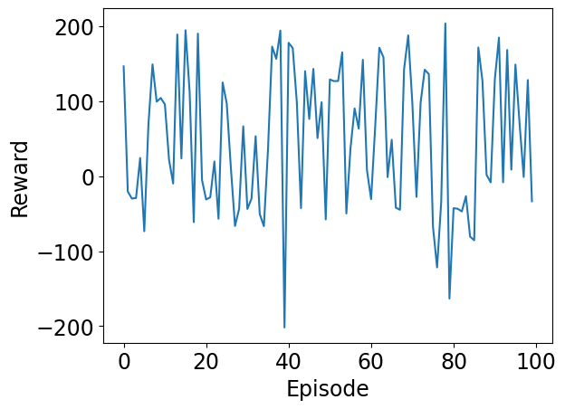

```python
plt.plot(history.history['episode_reward'])
plt.ylabel('Reward')
plt.xlabel('Episode')
plt.show()
```

## Building Deep Q-Network

Deep Q Networks (DQN) are a type of Reinforcement Learning (RL) algorithm that uses a neural network to approximate the Q-function, which is used to determine the optimal action to take in a given state. Its a variant of Q-learning, and we will be using experience replay to stabilize learning to improve performance.

## Parameters

- Learning Rate: It determines the size of the update steps taken by the algorithm to adjust the weights of the neural network.
- Gamma(γ): Also known as the discount factor, it determines the importance of future rewards compared to the present reward. The higher the value means that future rewards are considered more important. (0 < γ < 1)
- Epsilon (ε): Epsilon determines the balance between exploration and exploitation in the DQN algorithm, meaning that the higher the epsilon, the more likely it is to explore randomly.
- Epsilon Decay: It refers to the gradual reduction of the exploration rate over time. As th model becomes more confident, it becomes less necessary to explore and more important to exploit the learned knowledge. Thus, encouraging the agent to shift from a more exploratory to a more exploitative strategy.

```python
class DQN:
    def __init__(self, env, lr, gamma, epsilon, epsilon_decay):
        self.env = env
        self.action_space = env.action_space
        self.observation_space = env.observation_space
        self.counter = 0

        self.lr = lr
        self.gamma = gamma
        self.epsilon = epsilon
        self.epsilon_decay = epsilon_decay
        self.rewards_list = []

        self.replay_memory_buffer = deque(maxlen=500000)
        self.batch_size = 64
        self.epsilon_min = 0.01
        self.num_action_space = self.action_space.n
        self.num_observation_space = env.observation_space.shape[0]
        self.model = self.initialize_model()
        self.stats = pd.DataFrame(columns = ['Episode', 'Step','x-coor', 'y-coor', 'x-velo', 'y-velo', 'angle', 'angular velocity', 'left-touch', 'right-touch'])

    def initialize_model(self):
        model = tf.keras.Sequential()
        model.add(layers.Dense(512, input_dim=self.num_observation_space, activation='relu'))
        model.add(layers.Dense(256, activation='relu'))
        model.add(layers.Dense(self.num_action_space, activation=tf.keras.activations.linear))

        # Compile the model
        model.compile(loss=tf.keras.losses.mean_squared_error,optimizer=tf.keras.optimizers.Adam(lr=self.lr))
        print(model.summary())
        return model

    def get_action(self, state):
        if np.random.rand() < self.epsilon:
            return random.randrange(self.num_action_space)

        predicted_actions = self.model.predict(state)
        return np.argmax(predicted_actions[0])

    def add_to_replay_memory(self, state, action, reward, next_state, done):
        self.replay_memory_buffer.append((state, action, reward, next_state, done))

    def learn_and_update_weights_by_reply(self):
        # replay_memory_buffer size check
        if len(self.replay_memory_buffer) < self.batch_size or self.counter != 0:
            return

        # Early Stopping
        if np.mean(self.rewards_list[-10:]) > 180: #if average reward in last 10 episodes >180
            return

        random_sample = self.get_random_sample_from_replay_mem()
        states, actions, rewards, next_states, done_list = self.get_attributes_from_sample(random_sample)
        targets = rewards + self.gamma * (np.amax(self.model.predict_on_batch(next_states), axis=1)) * (1 - done_list)
        target_vec = self.model.predict_on_batch(states)
        indexes = np.array([i for i in range(self.batch_size)])
        target_vec[[indexes], [actions]] = targets

        self.model.fit(states, target_vec, epochs=1, verbose=0)

    def get_attributes_from_sample(self, random_sample):
        states = np.array([i[0] for i in random_sample])
        actions = np.array([i[1] for i in random_sample])
        rewards = np.array([i[2] for i in random_sample])
        next_states = np.array([i[3] for i in random_sample])
        done_list = np.array([i[4] for i in random_sample])
        states = np.squeeze(states)
        next_states = np.squeeze(next_states)
        return np.squeeze(states), actions, rewards, next_states, done_list

    def get_random_sample_from_replay_mem(self):
        random_sample = random.sample(self.replay_memory_buffer, self.batch_size)
        return random_sample

    def train(self, num_episodes=2000, can_stop=True,render=True):

        for episode in range(num_episodes):
            state = env.reset()
            reward_for_episode = 0
            num_steps = 1000
            state = np.reshape(state, [1, self.num_observation_space])
            for step in range(num_steps):
                # Recording the state every 100 steps
                if step % 100 == 0:
                    curr_stat = np.array([episode,step])
                    curr_stat = np.append(curr_stat,state)
                    self.stats.loc[len(self.stats)] = curr_stat
                if render:
                  env.render()
                received_action = self.get_action(state)
                # print("received_action:", received_action)
                next_state, reward, done, info = env.step(received_action)
                next_state = np.reshape(next_state, [1, self.num_observation_space])
                # Store the experience in replay memory
                self.add_to_replay_memory(state, received_action, reward, next_state, done)
                # add up rewards
                reward_for_episode += reward
                state = next_state
                self.update_counter()
                self.learn_and_update_weights_by_reply()

                if done:
                    break
            self.rewards_list.append(reward_for_episode)

            # Decay the epsilon after each experience completion
            if self.epsilon > self.epsilon_min:
                self.epsilon *= self.epsilon_decay

            # Check for breaking condition
            last_rewards_mean = np.mean(self.rewards_list[-100:])
            if last_rewards_mean > 200 and can_stop:
                print("DQN Training Complete...")
                break
            print(episode, "\t: Episode || Reward: ",reward_for_episode, "\t|| Average Reward: ",last_rewards_mean, "\t epsilon: ", self.epsilon)

    def update_counter(self):
        self.counter += 1
        step_size = 5
        self.counter = self.counter % step_size

    def save(self, name):
        self.model.save(name)
```

## Training Model

```python
#init environment
env = gym.make('LunarLander-v2')
# set seeds
env.seed(21)
np.random.seed(21)
```

```
Model: "sequential"
_________________________________________________________________
 Layer (type)                Output Shape              Param #
=================================================================
 dense (Dense)               (None, 512)               4608

 dense_1 (Dense)             (None, 256)               131328

 dense_2 (Dense)             (None, 4)                 1028

=================================================================
Total params: 136,964
Trainable params: 136,964
Non-trainable params: 0
_________________________________________________________________
```

[output cut: 448 more lines]

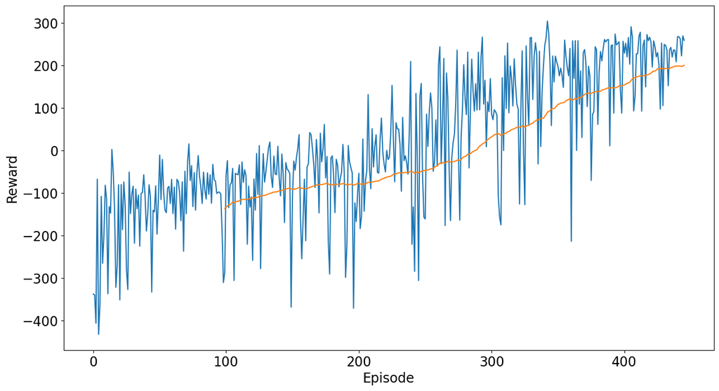

```python
# setting up params
lr = 0.001
epsilon = 1.0
epsilon_decay = 0.995
gamma = 0.99
training_episodes = 2000

#TRAINING
model = DQN(env, lr, gamma, epsilon, epsilon_decay)
model.train(training_episodes, can_stop=True, render=False) #stops after 200 reward mean

# Save trained model
model.save(save_dir + "/savedModels/DQNtrain.h5")

# Save Rewards list
pickle.dump(model.rewards_list, open(save_dir + "/train_rewards_list.p", "wb"))
rewards_list = pickle.load(open(save_dir + "/train_rewards_list.p", "rb"))
# plot reward in graph
reward_df = pd.DataFrame(rewards_list)
plot_df(reward_df, "Figure 1: Reward for each training episode", "Reward for each training episode", "Episode","Reward")

print("Training Complete")
```

## Hyperparameter Tuning

### Individual Experiments

```python
# Run experiments for hyper-parameter
run_experiment_for_lr() #best was 0.001
```

```
Running Experiment for learning rate...
Model: "sequential_2"
_________________________________________________________________
 Layer (type)                Output Shape              Param #
=================================================================
 dense_6 (Dense)             (None, 512)               4608

 dense_7 (Dense)             (None, 256)               131328

 dense_8 (Dense)             (None, 4)                 1028

=================================================================
Total params: 136,964
Trainable params: 136,964
Non-trainable params: 0
_________________________________________________________________
None
Training model for LR: 0.0001
```

```
0 	: Episode || Reward:  -120.6576081925607 	|| Average Reward:  -120.6576081925607 	 epsilon:  0.995
1 	: Episode || Reward:  -167.21760887808693 	|| Average Reward:  -143.93760853532382 	 epsilon:  0.990025
2 	: Episode || Reward:  -319.66021042634935 	|| Average Reward:  -202.51180916566568 	 epsilon:  0.985074875
3 	: Episode || Reward:  -89.42444758753625 	|| Average Reward:  -174.23996877113333 	 epsilon:  0.9801495006250001
4 	: Episode || Reward:  -11.729296487922852 	|| Average Reward:  -141.73783431449124 	 epsilon:  0.9752487531218751
5 	: Episode || Reward:  -64.5077685937465 	|| Average Reward:  -128.8661566943671 	 epsilon:  0.9703725093562657
6 	: Episode || Reward:  -479.09450086385175 	|| Average Reward:  -178.89877729000779 	 epsilon:  0.9655206468094844
7 	: Episode || Reward:  -120.61639726295901 	|| Average Reward:  -171.61347978662667 	 epsilon:  0.960693043575437
8 	: Episode || Reward:  -230.7938922944535 	|| Average Reward:  -178.18908117638523 	 epsilon:  0.9558895783575597
9 	: Episode || Reward:  -126.58263499658352 	|| Average Reward:  -173.02843655840505 	 epsilon:  0.9511101304657719
10 	: Episode || Reward:  -123.37869507103338 	|| Average Reward:  -168.5148236959167 	 epsilon:  0.946354579813443
11 	: Episode || Reward:  -230.57043302666358 	|| Average Reward:  -173.68612447347894 	 epsilon:  0.9416228069143757
12 	: Episode || Reward:  -53.6745819910372 	|| Average Reward:  -164.45446735944495 	 epsilon:  0.9369146928798039
13 	: Episode || Reward:  -101.27929464271116 	|| Average Reward:  -159.9419550225354 	 epsilon:  0.9322301194154049
14 	: Episode || Reward:  -75.4860540402297 	|| Average Reward:  -154.31156162371502 	 epsilon:  0.9275689688183278
```

[output cut: 2633 more lines]

[output not shown]

[output cut: 31 more lines]

[output not shown]

```
Running Experiment for epsilon decay...
Model: "sequential"
_________________________________________________________________
 Layer (type)                Output Shape              Param #
=================================================================
 dense (Dense)               (None, 512)               4608

 dense_1 (Dense)             (None, 256)               131328

 dense_2 (Dense)             (None, 4)                 1028

=================================================================
Total params: 136,964
Trainable params: 136,964
Non-trainable params: 0
_________________________________________________________________
None
Training model for ED: 0.999
```

```
0 	: Episode || Reward:  -324.5556752470919 	|| Average Reward:  -324.5556752470919 	 epsilon:  0.999
1 	: Episode || Reward:  -526.0115488950262 	|| Average Reward:  -425.28361207105905 	 epsilon:  0.998001
2 	: Episode || Reward:  -172.46898440720287 	|| Average Reward:  -341.0120695164403 	 epsilon:  0.997002999
3 	: Episode || Reward:  -383.397946554756 	|| Average Reward:  -351.60853877601926 	 epsilon:  0.996005996001
4 	: Episode || Reward:  -81.41497541598389 	|| Average Reward:  -297.5698261040122 	 epsilon:  0.995009990004999
5 	: Episode || Reward:  -108.99635737790021 	|| Average Reward:  -266.1409146496602 	 epsilon:  0.994014980014994
6 	: Episode || Reward:  -172.20223229039823 	|| Average Reward:  -252.72110288405136 	 epsilon:  0.993020965034979
7 	: Episode || Reward:  -211.60694166287732 	|| Average Reward:  -247.58183273140457 	 epsilon:  0.9920279440699441
8 	: Episode || Reward:  -42.456260746278346 	|| Average Reward:  -224.790102510835 	 epsilon:  0.9910359161258742
9 	: Episode || Reward:  -107.88353202595407 	|| Average Reward:  -213.09944546234686 	 epsilon:  0.9900448802097482
10 	: Episode || Reward:  -137.1798582243493 	|| Average Reward:  -206.19766480434708 	 epsilon:  0.9890548353295385
11 	: Episode || Reward:  -339.83283870286095 	|| Average Reward:  -217.3339292958899 	 epsilon:  0.988065780494209
12 	: Episode || Reward:  -372.9855858728376 	|| Average Reward:  -229.3071336479628 	 epsilon:  0.9870777147137147
13 	: Episode || Reward:  -222.16517361390174 	|| Average Reward:  -228.79699364552985 	 epsilon:  0.986090636999001
14 	: Episode || Reward:  -87.77259045349996 	|| Average Reward:  -219.3953667660612 	 epsilon:  0.9851045463620021
```

[output cut: 4036 more lines]

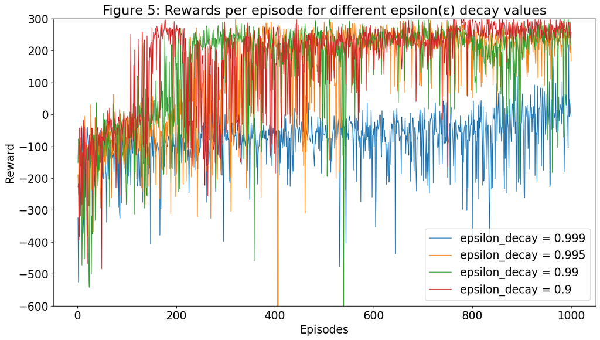

```python
run_experiment_for_ed()
```

```python
run_experiment_for_gamma()
```

```
Running Experiment for gamma...
Model: "sequential_4"
_________________________________________________________________
 Layer (type)                Output Shape              Param #
=================================================================
 dense_12 (Dense)            (None, 512)               4608

 dense_13 (Dense)            (None, 256)               131328

 dense_14 (Dense)            (None, 4)                 1028

=================================================================
Total params: 136,964
Trainable params: 136,964
Non-trainable params: 0
_________________________________________________________________
None
Training model for Gamma: 0.99
```

```
0 	: Episode || Reward:  -82.36959563029109 	|| Average Reward:  -82.36959563029109 	 epsilon:  0.995
1 	: Episode || Reward:  -228.94820600461387 	|| Average Reward:  -155.6589008174525 	 epsilon:  0.990025
2 	: Episode || Reward:  -249.4842624118481 	|| Average Reward:  -186.9340213489177 	 epsilon:  0.985074875
3 	: Episode || Reward:  7.306426528936257 	|| Average Reward:  -138.3739093794542 	 epsilon:  0.9801495006250001
4 	: Episode || Reward:  -185.78451193608038 	|| Average Reward:  -147.85602989077944 	 epsilon:  0.9752487531218751
5 	: Episode || Reward:  -126.6810806272296 	|| Average Reward:  -144.3268716801878 	 epsilon:  0.9703725093562657
6 	: Episode || Reward:  -230.55442999505823 	|| Average Reward:  -156.64509429659785 	 epsilon:  0.9655206468094844
7 	: Episode || Reward:  -154.07080003364553 	|| Average Reward:  -156.32330751372882 	 epsilon:  0.960693043575437
8 	: Episode || Reward:  -235.8646325842159 	|| Average Reward:  -165.16123252156072 	 epsilon:  0.9558895783575597
9 	: Episode || Reward:  -397.34442091498534 	|| Average Reward:  -188.37955136090318 	 epsilon:  0.9511101304657719
10 	: Episode || Reward:  -39.30714605862528 	|| Average Reward:  -174.82751451524155 	 epsilon:  0.946354579813443
11 	: Episode || Reward:  -104.42147523517808 	|| Average Reward:  -168.96034457523626 	 epsilon:  0.9416228069143757
12 	: Episode || Reward:  -625.1878418539187 	|| Average Reward:  -204.0547674428272 	 epsilon:  0.9369146928798039
13 	: Episode || Reward:  -140.4200748570607 	|| Average Reward:  -199.5094322581296 	 epsilon:  0.9322301194154049
14 	: Episode || Reward:  -149.83119572004304 	|| Average Reward:  -196.19754982225717 	 epsilon:  0.9275689688183278
```

[output cut: 3012 more lines]

### Best Parameters

- 0.9 epsilon decay: 266 avg reward
- 0.001 learning rate: 245 avg reward
- 0.99 gamma: 251 avg reward
- Now using these parameters we will retrain the model without stopping it so we can get the most learning output

```
Model: "sequential"
_________________________________________________________________
 Layer (type)                Output Shape              Param #
=================================================================
 dense (Dense)               (None, 512)               4608

 dense_1 (Dense)             (None, 256)               131328

 dense_2 (Dense)             (None, 4)                 1028

=================================================================
Total params: 136,964
Trainable params: 136,964
Non-trainable params: 0
_________________________________________________________________
None
```

```
0 	: Episode || Reward:  -94.6142176462809 	|| Average Reward:  -94.6142176462809 	 epsilon:  0.9
1 	: Episode || Reward:  -131.40664014318926 	|| Average Reward:  -113.01042889473509 	 epsilon:  0.81
2 	: Episode || Reward:  -72.48037221017223 	|| Average Reward:  -99.5004099998808 	 epsilon:  0.7290000000000001
3 	: Episode || Reward:  -256.3185667304044 	|| Average Reward:  -138.7049491825117 	 epsilon:  0.6561000000000001
4 	: Episode || Reward:  -175.10072045479163 	|| Average Reward:  -145.9841034369677 	 epsilon:  0.5904900000000002
5 	: Episode || Reward:  -128.682905269395 	|| Average Reward:  -143.1005704090389 	 epsilon:  0.5314410000000002
6 	: Episode || Reward:  -133.92502294288852 	|| Average Reward:  -141.78977791387456 	 epsilon:  0.47829690000000014
7 	: Episode || Reward:  -125.38519276509687 	|| Average Reward:  -139.73920477027735 	 epsilon:  0.43046721000000016
8 	: Episode || Reward:  -302.8926961281075 	|| Average Reward:  -157.86737047670292 	 epsilon:  0.38742048900000015
9 	: Episode || Reward:  -304.59183385109077 	|| Average Reward:  -172.53981681414172 	 epsilon:  0.34867844010000015
10 	: Episode || Reward:  -230.49695261234316 	|| Average Reward:  -177.80864734125092 	 epsilon:  0.31381059609000017
11 	: Episode || Reward:  -61.60799004897999 	|| Average Reward:  -168.12525923356168 	 epsilon:  0.28242953648100017
12 	: Episode || Reward:  -352.923795925179 	|| Average Reward:  -182.34053128676302 	 epsilon:  0.25418658283290013
13 	: Episode || Reward:  -413.6927068907344 	|| Average Reward:  -198.8656866870467 	 epsilon:  0.22876792454961012
14 	: Episode || Reward:  -123.1313642334917 	|| Average Reward:  -193.8167318568097 	 epsilon:  0.2058911320946491
```

[output cut: 1986 more lines]

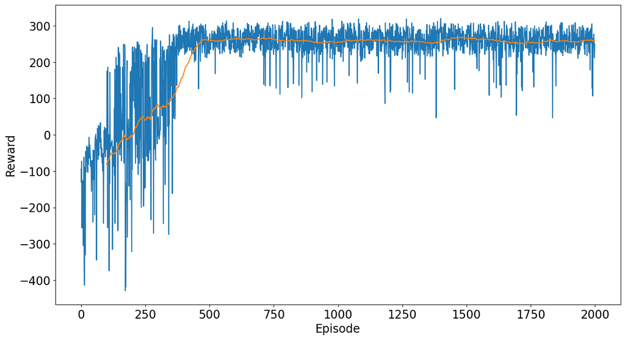

```python
#init environment
env = gym.make('LunarLander-v2')

# set seeds
env.seed(21)
np.random.seed(21)
# setting up hypertuned params
lr = 0.001
epsilon = 1.0
epsilon_decay = 0.9
gamma = 0.99
training_episodes = 2000
model = DQN(env, lr, gamma, epsilon, epsilon_decay)
model.train(training_episodes,  can_stop=False)

save_dir = "0-COLLAB"
# Save trained model
model.save(save_dir + "/savedModels/tuned_model.h5")

# Save Rewards list
pickle.dump(model.rewards_list, open(save_dir + "/train_rewards_list.p", "wb"))
rewards_list = pickle.load(open(save_dir + "/train_rewards_list.p", "rb"))
# plot reward in graph
reward_df = pd.DataFrame(rewards_list)
plot_df(reward_df, "Figure 1: Reward for each training episode", "Reward for each training episode", "Episode","Reward")
print("Training Complete")
```

```python
rewards_list = pickle.load(open(save_dir + "/train_rewards_list.p", "rb"))
print(rewards_list)
```

[output not shown]

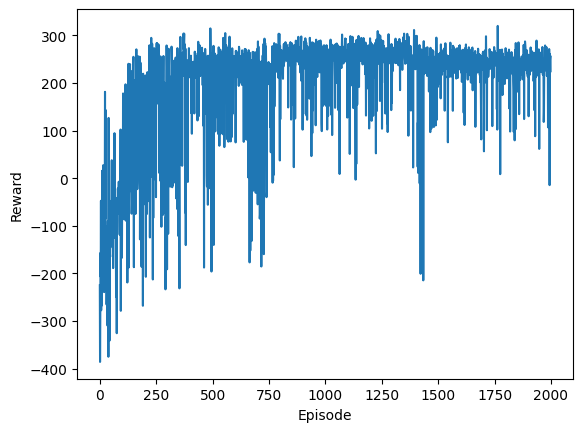

```python
plt.plot(rewards_list)
plt.ylabel('Reward')
plt.xlabel('Episode')
plt.show()
```

### Plot environment variable data

```python
df = model.stats
df.to_csv('1-COLLAB/df.csv')
```

[output not shown]

```python
df=pd.read_csv('0-COLLAB/df.csv').drop(['Unnamed: 0'],axis=1)
df
```

[output not shown]

9279 rows × 11 columns

#### Plot angle of ship over time during training

We can see that there are much more spikes at the beginning of training, indicating that the ship was angled more sharply at the beginning as the model did not know what it was doing, it would just rotate 90 degrees and fly to the ground and crash. Overtime the general trend is the angle decreasing as the model learns to fly the ship with more stability.

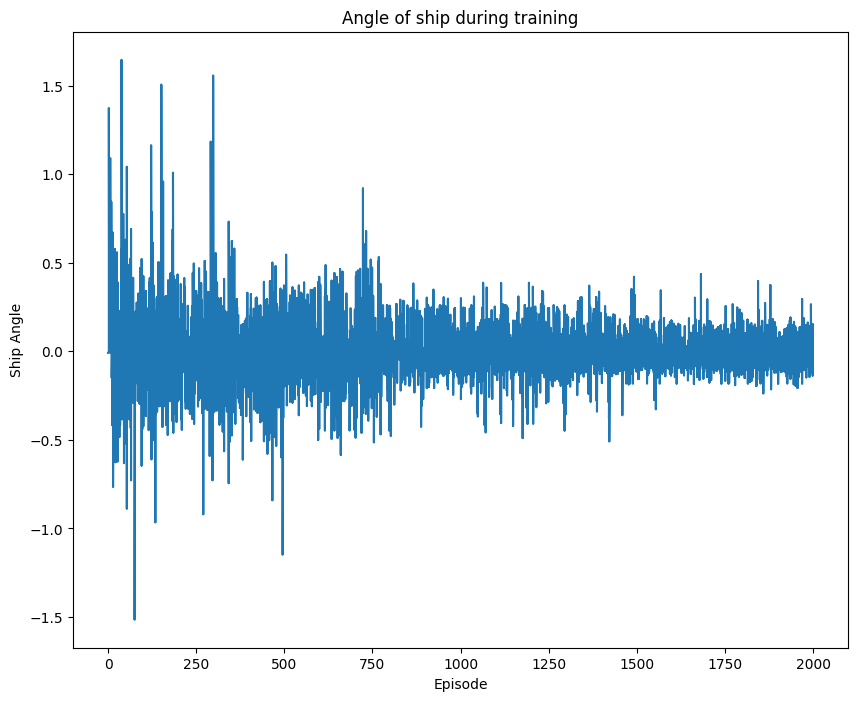

```python
plt.figure(figsize=(10,8))
plt.plot(df['Episode'], df['angle'])
plt.ylabel('Ship Angle')
plt.xlabel('Episode')
plt.title('Angle of ship during training')
plt.show()
```

#### Plot ship's velocity over time

```python
df['avgVelocity']=(df['x-velo']+df['y-velo'])/2
#aggregate per episode
df1=df.drop(['Step','left-touch','right-touch'],axis=1)
df1=df1.groupby(['Episode']).mean()
```

```python
df1
```

| Episode | x-coor | y-coor | x-velo | y-velo | angle | angular velocity | avgVelocity |
| --- | --- | --- | --- | --- | --- | --- | --- |
| 0.0 | 0.007867 | 1.403290 | 0.796822 | -0.339118 | -0.009109 | -0.180492 | 0.228852 |
| 1.0 | 0.007531 | 1.417743 | 0.762784 | 0.303201 | -0.008720 | -0.172782 | 0.532993 |
| 2.0 | -0.315587 | 0.818836 | -0.709947 | -0.556275 | 0.688869 | -0.005151 | -0.633111 |
| 3.0 | -0.006106 | 1.408382 | -0.618442 | -0.112827 | 0.007082 | 0.140086 | -0.365635 |
| 4.0 | 0.001496 | 1.405310 | 0.151507 | -0.249340 | -0.001727 | -0.034318 | -0.048916 |
| ... | ... | ... | ... | ... | ... | ... | ... |
| 1995.0 | -0.162766 | 0.624484 | -0.039890 | -0.033655 | -0.017052 | 0.020862 | -0.036772 |
| 1996.0 | -0.138080 | 0.592702 | -0.013272 | -0.016776 | -0.007533 | 0.038175 | -0.015024 |
| 1997.0 | -0.106357 | 0.608169 | -0.085959 | -0.174567 | 0.006738 | 0.010749 | -0.130263 |
| 1998.0 | 0.028398 | 0.684516 | 0.026080 | -0.105885 | 0.013882 | -0.036278 | -0.039902 |
| 1999.0 | 0.083599 | 0.524850 | 0.067848 | -0.098942 | 0.003662 | -0.051526 | -0.015547 |

2000 rows × 7 columns

Similar to earlier, there are much less spikes in velocity when training goes on. This makes sense because the ship must maintain a relatively low velocity to land safely. In the region of ~400-600 episodes, we can see there is a trough in avg x-velocity. This could mean that the ship is barely moving away from the original position horizontally, this can be bad because the ship usually must move some amount to get into the landing pad area.

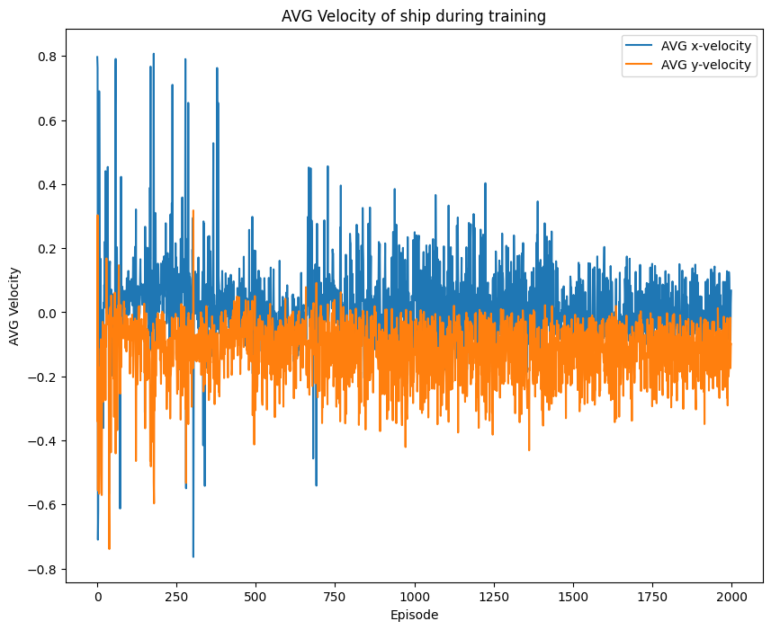

```python
plt.figure(figsize=(10,8))
# plt.plot( df1['avgVelocity'],label='avg-velocity')
plt.plot( df1['x-velo'],label='AVG x-velocity')
plt.plot( df1['y-velo'],label='AVG y-velocity')
plt.ylabel('AVG Velocity')
plt.xlabel('Episode')
plt.title('AVG Velocity of ship during training')
plt.legend()
plt.show()
```

## Test Final Model

```python
#load from h5 file
loadedModel=tf.keras.models.load_model('0-COLLAB/savedModels/tunedDeepQ.h5')
```

```
Starting Testing of the trained model...
0 	: Episode || Reward:  244.35411178559286
1 	: Episode || Reward:  251.57839834856287
2 	: Episode || Reward:  295.44750480383453
3 	: Episode || Reward:  238.93842355962568
4 	: Episode || Reward:  146.55867690560592
5 	: Episode || Reward:  289.59182841007146
6 	: Episode || Reward:  295.22863640369513
7 	: Episode || Reward:  249.1746177978875
8 	: Episode || Reward:  272.5341066700867
9 	: Episode || Reward:  247.03422464740345
10 	: Episode || Reward:  304.5035099297452
11 	: Episode || Reward:  223.66612561041734
12 	: Episode || Reward:  269.47445175659857
13 	: Episode || Reward:  303.58726805295646
```

[output cut: 86 more lines]

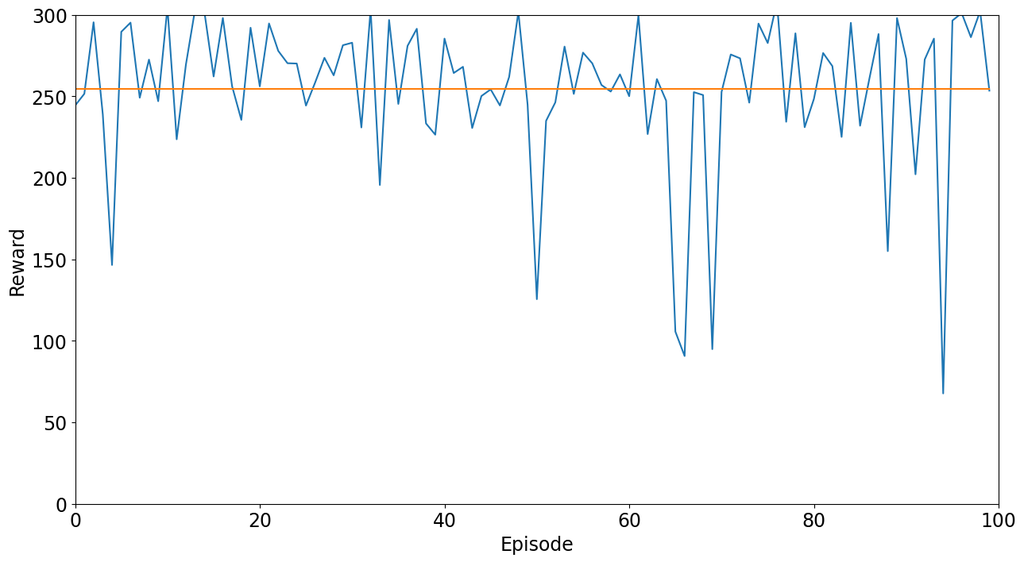

```python
test_rewards = test_already_trained_model(loadedModel,episodes=100,render=True)
plot_df2(pd.DataFrame(test_rewards), "Figure 2: Reward for each testing episode","Reward for each testing episode", "Episode", "Reward")
pickle.dump(test_rewards, open(save_dir + "/test_rewards.p", "wb"))
```

# Conclusion

A great result from our final model which consistently lands the ship in the landing area with high consistency, and lands the ship in general with even higher consistency. We learned how to implement different RL Architectures/Algorithms as well as how to tune them properly.

```python
#zip up outputs
import shutil
shutil.make_archive('finalOutputs', 'tar', '0-COLLAB')
```

```
'C:\\Users\\jayde\\finalOutputs.tar'
```